# Recell_Project_v2

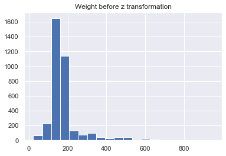

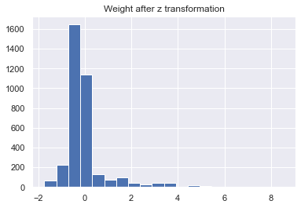

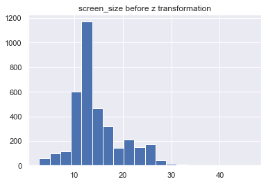

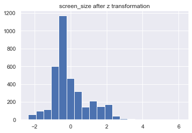

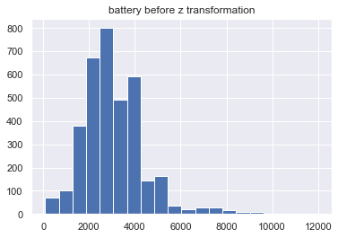

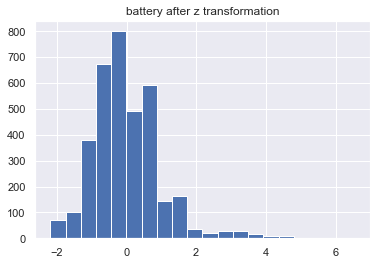

```python
from sklearn.preprocessing import StandardScaler, MinMaxScaler

# analyze weight,battery and screen size  variable to apply any transformations

std_scaler = StandardScaler()

data["weight"].hist(bins=20)
plt.title("Weight before z transformation")
plt.show()

data["weight_z_std"] = std_scaler.fit_transform(df[["weight"]])
data["weight_z_std"].hist(bins=20)
plt.title("Weight after z transformation")
plt.show()

data.drop(["weight"], axis=1, inplace=True)

data["screen_size"].hist(bins=20)
plt.title("screen_size before z transformation")
plt.show()

data["screen_size_z_std"] = std_scaler.fit_transform(df[["screen_size"]])
data["screen_size_z_std"].hist(bins=20)
plt.title("screen_size after z transformation")
plt.show()

data.drop(["screen_size"], axis=1, inplace=True)


data["battery"].hist(bins=20)
plt.title("battery before z transformation")
plt.show()

data["battery_z_std"] = std_scaler.fit_transform(df[["battery"]])
data["battery_z_std"].hist(bins=20)
plt.title("battery after z transformation")
plt.show()
data.drop(["battery"], axis=1, inplace=True)
```

- Observations
1. Based off the above it is better to apply the standard scaler on these 3 variables

```python
# Check for missing values after applying the transformations
data.isnull().sum()
```

```
brand_name           0
os                   0
4g                   0
5g                   0
main_camera_mp       0
selfie_camera_mp     0
int_memory           0
ram                  0
days_used            0
new_price            0
used_price           0
weight_z_std         7
screen_size_z_std    0
battery_z_std        6
dtype: int64
```

- Observations
1. Based off the above,there are missing values in weight_z_std and battery_z_std.

```python
# counting the number of missing values per row
data.isnull().sum(axis=1).value_counts()
```

```
0    3558
1      13
dtype: int64
```

```python
# impute the mean value for those missing value
data["battery_z_std"].fillna(
    data["battery_z_std"].mean(), inplace=True
)  # mean imputation
data["weight_z_std"].fillna(
    data["weight_z_std"].mean(), inplace=True
)  # mean imputation
```

## Linear Model Building

#### We want to predict the price of a used phone

#### Before we proceed to build a model, we will encode categorical features.

#### We'll split the data into train and test to be able to evaluate the model that we build on the train data.

#### We will build a Linear Regression model using the train data and then check it's performance.

```python
X = data.drop("used_price", axis=1)
y = data["used_price"]

print(X.head())
print(y.head())
```

```
  brand_name       os   4g   5g  main_camera_mp  selfie_camera_mp  int_memory  \
0      Honor  Android  yes   no            13.0               5.0        64.0
1      Honor  Android  yes  yes            13.0              16.0       128.0
2      Honor  Android  yes  yes            13.0               8.0       128.0
3      Honor  Android  yes  yes            13.0               8.0        64.0
4      Honor  Android  yes   no            13.0               8.0        64.0

   ram  days_used  new_price  weight_z_std  screen_size_z_std  battery_z_std
0  3.0        127   4.724019     -0.370278           1.779008      -0.034623
1  8.0        325   5.523020      0.371955           2.580581       0.903783
2  8.0        162   5.887409      0.371955           1.841115       0.830470
3  6.0        345   5.634540      3.329808           2.180765       3.066516
4  3.0        293   4.954911      0.061768           0.177803       1.416974
0    4.476882
1    5.090616
2    5.596754
3    5.199767
4    4.652054
Name: used_price, dtype: float64
```

```python
X = pd.get_dummies(
    X,
    columns=X.select_dtypes(include=["object", "category"]).columns.tolist(),
    drop_first=True,
)
X.head()
```

|  | main_camera_mp | selfie_camera_mp | int_memory | ram | days_used | new_price | weight_z_std | screen_size_z_std | battery_z_std | brand_name_Alcatel | ... | brand_name_Spice | brand_name_Vivo | brand_name_XOLO | brand_name_Xiaomi | brand_name_ZTE | os_Others | os_Windows | os_iOS | 4g_yes | 5g_yes |
| --- | --- | --- | --- | --- | --- | --- | --- | --- | --- | --- | --- | --- | --- | --- | --- | --- | --- | --- | --- | --- | --- |
| 0 | 13.0 | 5.0 | 64.0 | 3.0 | 127 | 4.724019 | -0.370278 | 1.779008 | -0.034623 | 0 | ... | 0 | 0 | 0 | 0 | 0 | 0 | 0 | 0 | 1 | 0 |
| 1 | 13.0 | 16.0 | 128.0 | 8.0 | 325 | 5.523020 | 0.371955 | 2.580581 | 0.903783 | 0 | ... | 0 | 0 | 0 | 0 | 0 | 0 | 0 | 0 | 1 | 1 |
| 2 | 13.0 | 8.0 | 128.0 | 8.0 | 162 | 5.887409 | 0.371955 | 1.841115 | 0.830470 | 0 | ... | 0 | 0 | 0 | 0 | 0 | 0 | 0 | 0 | 1 | 1 |
| 3 | 13.0 | 8.0 | 64.0 | 6.0 | 345 | 5.634540 | 3.329808 | 2.180765 | 3.066516 | 0 | ... | 0 | 0 | 0 | 0 | 0 | 0 | 0 | 0 | 1 | 1 |
| 4 | 13.0 | 8.0 | 64.0 | 3.0 | 293 | 4.954911 | 0.061768 | 0.177803 | 1.416974 | 0 | ... | 0 | 0 | 0 | 0 | 0 | 0 | 0 | 0 | 1 | 0 |

5 rows × 47 columns

```python
# splitting the data in 70:30 ratio for train to test data

x_train, x_test, y_train, y_test = train_test_split(
    X, y, test_size=0.3, random_state=42
)
```

```python
print("Number of rows in train data =", x_train.shape[0])
print("Number of rows in test data =", x_test.shape[0])
```

```
Number of rows in train data = 2499
Number of rows in test data = 1072
```

```python
# fitting the linear regression model on the train data (70% of the whole data)

linearregression = LinearRegression()
linearregression.fit(x_train, y_train)
```

```
LinearRegression()
```

### Let's check the coefficients and intercept of the model.

```python
coef_df = pd.DataFrame(
    np.append(linearregression.coef_, linearregression.intercept_),
    index=x_train.columns.tolist() + ["Intercept"],
    columns=["Coefficients"],
)

coef_df
```

|  | Coefficients |
| --- | --- |
| main_camera_mp | 0.000530 |
| selfie_camera_mp | 0.001259 |
| int_memory | 0.000039 |
| ram | 0.000108 |
| days_used | -0.001104 |
| new_price | 0.978323 |
| weight_z_std | -0.002766 |
| screen_size_z_std | 0.001890 |
| battery_z_std | 0.006048 |
| brand_name_Alcatel | 0.004013 |
| brand_name_Apple | 0.079301 |
| brand_name_Asus | 0.010933 |
| brand_name_BlackBerry | -0.016128 |
| brand_name_Celkon | 0.025136 |
| brand_name_Coolpad | 0.043658 |
| brand_name_Gionee | -0.026562 |
| brand_name_Google | 0.016560 |
| brand_name_HTC | 0.021413 |
| brand_name_Honor | 0.022476 |
| brand_name_Huawei | 0.014303 |
| brand_name_Infinix | 0.036959 |
| brand_name_Karbonn | -0.004709 |
| brand_name_LG | 0.024284 |
| brand_name_Lava | 0.008586 |
| brand_name_Lenovo | -0.003463 |
| brand_name_Meizu | 0.023512 |
| brand_name_Micromax | 0.011011 |
| brand_name_Microsoft | -0.001410 |
| brand_name_Motorola | 0.008704 |
| brand_name_Nokia | 0.006934 |
| brand_name_OnePlus | 0.037644 |
| brand_name_Oppo | 0.008956 |
| brand_name_Others | 0.017295 |
| brand_name_Panasonic | 0.004623 |
| brand_name_Realme | 0.023536 |
| brand_name_Samsung | 0.021470 |
| brand_name_Sony | 0.003135 |
| brand_name_Spice | 0.007947 |
| brand_name_Vivo | -0.000929 |
| brand_name_XOLO | 0.016042 |
| brand_name_Xiaomi | 0.012574 |
| brand_name_ZTE | 0.005629 |
| os_Others | 0.002869 |
| os_Windows | -0.002391 |
| os_iOS | -0.056840 |
| 4g_yes | -0.009108 |
| 5g_yes | 0.032691 |
| Intercept | -0.030941 |

### Let's check the performance of the model using different metrics.

#### We will be using metric functions defined in sklearn for RMSE, MAE, and 𝑅2 .

#### We will define a function to calculate MAPE and adjusted 𝑅2 .

#### The mean absolute percentage error (MAPE) measures the accuracy of predictions as a percentage, and can be calculated as the average absolute percent error for each predicted value minus actual values divided by actual values. It works best if there are no extreme values in the data and none of the actual values are 0.

#### We will create a function which will print out all the above metrics in one go.

```python
# function to compute adjusted R-squared
def adj_r2_score(predictors, targets, predictions):
    r2 = r2_score(targets, predictions)
    n = predictors.shape[0]
    k = predictors.shape[1]
    return 1 - ((1 - r2) * (n - 1) / (n - k - 1))


# function to compute MAPE
def mape_score(targets, predictions):
    return np.mean(np.abs(targets - predictions) / targets) * 100


# function to compute different metrics to check performance of a regression model
def model_performance_regression(model, predictors, target):
    """
    Function to compute different metrics to check regression model performance

    model: regressor
    predictors: independent variables
    target: dependent variable
    """

    # predicting using the independent variables
    pred = model.predict(predictors)

    r2 = r2_score(target, pred)  # to compute R-squared
    adjr2 = adj_r2_score(predictors, target, pred)  # to compute adjusted R-squared
    rmse = np.sqrt(mean_squared_error(target, pred))  # to compute RMSE
    mae = mean_absolute_error(target, pred)  # to compute MAE
    mape = mape_score(target, pred)  # to compute MAPE

    # creating a dataframe of metrics
    df_perf = pd.DataFrame(
        {
            "RMSE": rmse,
            "MAE": mae,
            "R-squared": r2,
            "Adj. R-squared": adjr2,
            "MAPE": mape,
        },
        index=[0],
    )

    return df_perf
```

```python
# checking model performance on train set (seen 70% data)
print("Training Performance\n")
linearregression_train_perf = model_performance_regression(
    linearregression, x_train, y_train
)
linearregression_train_perf
```

```
Training Performance
```

|  | RMSE | MAE | R-squared | Adj. R-squared | MAPE |
| --- | --- | --- | --- | --- | --- |
| 0 | 0.081679 | 0.067637 | 0.990116 | 0.989927 | 1.653169 |

```python
# checking model performance on test set (seen 30% data)
print("Test Performance\n")
linearregression_test_perf = model_performance_regression(
    linearregression, x_test, y_test
)
linearregression_test_perf
```

```
Test Performance
```

|  | RMSE | MAE | R-squared | Adj. R-squared | MAPE |
| --- | --- | --- | --- | --- | --- |
| 0 | 0.081059 | 0.069047 | 0.989761 | 0.989291 | 1.650752 |

### Observations

#### The training 𝑅2 is 99.0%, indicating that the model explains 99.0% of the variation in the train data. So, the model is not underfitting.

### MAE and RMSE on the train and test sets are comparable, which shows that the model is not overfitting.

### MAE indicates that our current model is able to predict used price within a mean error of 0.069 euros on the test data.

### MAPE on the test set suggests we can predict within 1.65% of the used price.

## Linear Regression using statsmodels

### Let's build a linear regression model using statsmodels.

```python
# unlike sklearn, statsmodels does not add a constant to the data on its own
# we have to add the constant manually
x_train1 = sm.add_constant(x_train)
# adding constant to the test data
x_test1 = sm.add_constant(x_test)

olsmod0 = sm.OLS(y_train, x_train1).fit()
print(olsmod0.summary())
```

```
                            OLS Regression Results
==============================================================================
Dep. Variable:             used_price   R-squared:                       0.990
Model:                            OLS   Adj. R-squared:                  0.990
Method:                 Least Squares   F-statistic:                     5224.
Date:                Fri, 20 Aug 2021   Prob (F-statistic):               0.00
Time:                        21:42:15   Log-Likelihood:                 2713.9
No. Observations:                2499   AIC:                            -5332.
Df Residuals:                    2451   BIC:                            -5052.
Df Model:                          47
Covariance Type:            nonrobust
=========================================================================================
                            coef    std err          t      P>|t|      [0.025      0.975]
-----------------------------------------------------------------------------------------
const                    -0.0309      0.023     -1.317      0.188      -0.077       0.015
main_camera_mp            0.0005      0.001      1.027      0.305      -0.000       0.002
selfie_camera_mp          0.0013      0.000      3.358      0.001       0.001       0.002
int_memory             3.906e-05    2.2e-05      1.776      0.076   -4.07e-06    8.22e-05
ram                       0.0001      0.002      0.067      0.946      -0.003       0.003
days_used                -0.0011   9.08e-06   -121.623      0.000      -0.001      -0.001
new_price                 0.9783      0.004    251.783      0.000       0.971       0.986
weight_z_std             -0.0028      0.003     -0.866      0.387      -0.009       0.003
screen_size_z_std         0.0019      0.003      0.622      0.534      -0.004       0.008
battery_z_std             0.0060      0.003      1.758      0.079      -0.001       0.013
brand_name_Alcatel        0.0040      0.017      0.232      0.817      -0.030       0.038
brand_name_Apple          0.0793      0.062      1.280      0.201      -0.042       0.201
brand_name_Asus           0.0109      0.017      0.634      0.526      -0.023       0.045
brand_name_BlackBerry    -0.0161      0.027     -0.595      0.552      -0.069       0.037
brand_name_Celkon         0.0251      0.023      1.113      0.266      -0.019       0.069
brand_name_Coolpad        0.0437      0.027      1.634      0.102      -0.009       0.096
brand_name_Gionee        -0.0266      0.020     -1.331      0.183      -0.066       0.013
brand_name_Google         0.0166      0.028      0.586      0.558      -0.039       0.072
brand_name_HTC            0.0214      0.018      1.221      0.222      -0.013       0.056
brand_name_Honor          0.0225      0.018      1.272      0.203      -0.012       0.057
brand_name_Huawei         0.0143      0.016      0.885      0.376      -0.017       0.046
brand_name_Infinix        0.0370      0.037      0.989      0.323      -0.036       0.110
brand_name_Karbonn       -0.0047      0.023     -0.208      0.836      -0.049       0.040
brand_name_LG             0.0243      0.016      1.493      0.136      -0.008       0.056
brand_name_Lava           0.0086      0.022      0.393      0.694      -0.034       0.051
brand_name_Lenovo        -0.0035      0.017     -0.208      0.836      -0.036       0.029
```

[output cut: 18 more lines]

```
os_Windows               -0.0024      0.016     -0.151      0.880      -0.034       0.029
os_iOS                   -0.0568      0.062     -0.924      0.356      -0.178       0.064
4g_yes                   -0.0091      0.005     -1.803      0.071      -0.019       0.001
5g_yes                    0.0327      0.011      2.997      0.003       0.011       0.054
==============================================================================
Omnibus:                      177.479   Durbin-Watson:                   2.033
Prob(Omnibus):                  0.000   Jarque-Bera (JB):              296.552
Skew:                          -0.536   Prob(JB):                     4.02e-65
Kurtosis:                       4.303   Cond. No.                     4.00e+04
==============================================================================

Notes:
[1] Standard Errors assume that the covariance matrix of the errors is correctly specified.
[2] The condition number is large,  4e+04. This might indicate that there are
strong multicollinearity or other numerical problems.
```

### Negative values of the coefficient show that used price decreases with the increase of corresponding attribute value.

### Positive values of the coefficient show that used price increases with the increase of corresponding attribute value.

### p-value of a variable indicates if the variable is significant or not. If we consider the significance level to be 0.05 (5%), then any variable with a p-value less than 0.05 would be considered significant.

### But these variables might contain multicollinearity, which will affect the p-values.

### So, we need to deal with multicollinearity and check the other assumptions of linear regression first, and then look at the p-values.

## Checking Linear Regression Assumptions

## We will be checking the following Linear Regression assumptions:

1. No Multicollinearity
2. Linearity of variables
3. Independence of error terms
4. Normality of error terms
5. No Heteroscedasticity

```python
from statsmodels.stats.outliers_influence import variance_inflation_factor

# we will define a function to check VIF
def checking_vif(predictors):
    vif = pd.DataFrame()
    vif["feature"] = predictors.columns

    # calculating VIF for each feature
    vif["VIF"] = [
        variance_inflation_factor(predictors.values, i)
        for i in range(len(predictors.columns))
    ]
    return vif
```

```python
checking_vif(x_train1)
```

|  | feature | VIF |
| --- | --- | --- |
| 0 | const | 202.727243 |
| 1 | main_camera_mp | 2.193318 |
| 2 | selfie_camera_mp | 2.505892 |
| 3 | int_memory | 1.286696 |
| 4 | ram | 1.795820 |
| 5 | days_used | 1.903844 |
| 6 | new_price | 2.871151 |
| 7 | weight_z_std | 3.498041 |
| 8 | screen_size_z_std | 3.347417 |
| 9 | battery_z_std | 4.151082 |
| 10 | brand_name_Alcatel | 3.494147 |
| 11 | brand_name_Apple | 21.663559 |
| 12 | brand_name_Asus | 3.626418 |
| 13 | brand_name_BlackBerry | 1.505320 |
| 14 | brand_name_Celkon | 2.002232 |
| 15 | brand_name_Coolpad | 1.461682 |
| 16 | brand_name_Gionee | 2.190496 |
| 17 | brand_name_Google | 1.402371 |
| 18 | brand_name_HTC | 3.417315 |
| 19 | brand_name_Honor | 3.723668 |
| 20 | brand_name_Huawei | 6.474205 |
| 21 | brand_name_Infinix | 1.229841 |
| 22 | brand_name_Karbonn | 1.725010 |
| 23 | brand_name_LG | 5.619223 |
| 24 | brand_name_Lava | 1.873352 |
| 25 | brand_name_Lenovo | 4.409480 |
| 26 | brand_name_Meizu | 2.403279 |
| 27 | brand_name_Micromax | 3.578851 |
| 28 | brand_name_Microsoft | 2.078702 |
| 29 | brand_name_Motorola | 3.833550 |
| 30 | brand_name_Nokia | 3.951515 |
| 31 | brand_name_OnePlus | 1.604452 |
| 32 | brand_name_Oppo | 4.096726 |
| 33 | brand_name_Others | 10.560163 |
| 34 | brand_name_Panasonic | 2.108750 |
| 35 | brand_name_Realme | 1.857107 |
| 36 | brand_name_Samsung | 8.458050 |
| 37 | brand_name_Sony | 2.895073 |
| 38 | brand_name_Spice | 1.637593 |
| 39 | brand_name_Vivo | 3.485909 |
| 40 | brand_name_XOLO | 2.119004 |
| 41 | brand_name_Xiaomi | 4.195314 |
| 42 | brand_name_ZTE | 3.584539 |
| 43 | os_Others | 1.707061 |
| 44 | os_Windows | 1.742486 |
| 45 | os_iOS | 20.290820 |
| 46 | 4g_yes | 2.119012 |
| 47 | 5g_yes | 1.727644 |

```python
# transfer the data into a dataframe and look for features that show moderate and high multicollinearity
vif_df = pd.DataFrame(checking_vif(x_train1))
vif_df[vif_df.VIF > 6.0000].sort_values(by=["VIF"], ascending=False)
```

|  | feature | VIF |
| --- | --- | --- |
| 0 | const | 202.727243 |
| 11 | brand_name_Apple | 21.663559 |
| 45 | os_iOS | 20.290820 |
| 33 | brand_name_Others | 10.560163 |
| 36 | brand_name_Samsung | 8.458050 |
| 20 | brand_name_Huawei | 6.474205 |

- Observations
1. Brands Apple has high VIF value of 21.66,followed by Others of 10.56 and then Samsung having a value of 8.45.Huawei has a VIF of 6.47
2. The iOS operating system has a high VIF value of 20.29

### Removing Multicollinearity

#### To remove multicollinearity

#### Drop every column one by one that has a VIF score greater than 5.

#### Look at the adjusted R-squared and RMSE of all these models.

#### Drop the variable that makes the least change in adjusted R-squared.

#### Check the VIF scores again.

#### Continue till you get all VIF scores under 5.

#### Let's define a function that will help us do this.

```python
def treating_multicollinearity(predictors, target, high_vif_columns):
    """
    Checking the effect of dropping the columns showing high multicollinearity
    on model performance (adj. R-squared and RMSE)

    predictors: independent variables
    target: dependent variable
    high_vif_columns: columns having high VIF
    """
    # empty lists to store adj. R-squared and RMSE values
    adj_r2 = []
    rmse = []

    # build ols models by dropping one of the high VIF columns at a time
    # store the adjusted R-squared and RMSE in the lists defined previously
    for cols in high_vif_columns:
        # defining the new train set
        train = predictors.loc[:, ~predictors.columns.str.startswith(cols)]

        # create the model
        olsmodel = sm.OLS(target, train).fit()

        # adding adj. R-squared and RMSE to the lists
        adj_r2.append(olsmodel.rsquared_adj)
        rmse.append(np.sqrt(olsmodel.mse_resid))

    # creating a dataframe for the results
    temp = pd.DataFrame(
        {
            "col": high_vif_columns,
            "Adj. R-squared after_dropping col": adj_r2,
            "RMSE after dropping col": rmse,
        }
    ).sort_values(by="Adj. R-squared after_dropping col", ascending=False)
    temp.reset_index(drop=True, inplace=True)

    return temp
```

```python
col_list = [
    "brand_name_Apple",
    "os_iOS",
    "brand_name_Others",
    "brand_name_Samsung",
    "brand_name_Huawei",
]

res = treating_multicollinearity(x_train1, y_train, col_list)
res
```

|  | col | Adj. R-squared after_dropping col | RMSE after dropping col |
| --- | --- | --- | --- |
| 0 | brand_name_Huawei | 0.989928 | 0.082472 |
| 1 | os_iOS | 0.989927 | 0.082473 |
| 2 | brand_name_Others | 0.989926 | 0.082480 |
| 3 | brand_name_Apple | 0.989924 | 0.082486 |
| 4 | brand_name_Samsung | 0.989923 | 0.082490 |

#### We'll drop Huawei and check the VIF again.

```python
col_to_drop = "brand_name_Huawei"
x_train2 = x_train1.loc[:, ~x_train1.columns.str.startswith(col_to_drop)]
x_test2 = x_test1.loc[:, ~x_test1.columns.str.startswith(col_to_drop)]

# Check VIF now
vif = checking_vif(x_train2)
print("VIF after dropping ", col_to_drop)
vif
```

```
VIF after dropping  brand_name_Huawei
```

|  | feature | VIF |
| --- | --- | --- |
| 0 | const | 139.116546 |
| 1 | main_camera_mp | 2.192915 |
| 2 | selfie_camera_mp | 2.498761 |
| 3 | int_memory | 1.284970 |
| 4 | ram | 1.795732 |
| 5 | days_used | 1.903795 |
| 6 | new_price | 2.871076 |
| 7 | weight_z_std | 3.492382 |
| 8 | screen_size_z_std | 3.346558 |
| 9 | battery_z_std | 4.146687 |
| 10 | brand_name_Alcatel | 1.408868 |
| 11 | brand_name_Apple | 20.533458 |
| 12 | brand_name_Asus | 1.393884 |
| 13 | brand_name_BlackBerry | 1.113715 |
| 14 | brand_name_Celkon | 1.308136 |
| 15 | brand_name_Coolpad | 1.073925 |
| 16 | brand_name_Gionee | 1.187052 |
| 17 | brand_name_Google | 1.068685 |
| 18 | brand_name_HTC | 1.374283 |
| 19 | brand_name_Honor | 1.400734 |
| 20 | brand_name_Infinix | 1.057174 |
| 21 | brand_name_Karbonn | 1.148308 |
| 22 | brand_name_LG | 1.688004 |
| 23 | brand_name_Lava | 1.177876 |
| 24 | brand_name_Lenovo | 1.511243 |
| 25 | brand_name_Meizu | 1.201816 |
| 26 | brand_name_Micromax | 1.475593 |
| 27 | brand_name_Microsoft | 1.678793 |
| 28 | brand_name_Motorola | 1.435617 |
| 29 | brand_name_Nokia | 1.664180 |
| 30 | brand_name_OnePlus | 1.111387 |
| 31 | brand_name_Oppo | 1.462897 |
| 32 | brand_name_Others | 2.457869 |
| 33 | brand_name_Panasonic | 1.179265 |
| 34 | brand_name_Realme | 1.145292 |
| 35 | brand_name_Samsung | 2.084179 |
| 36 | brand_name_Sony | 1.317549 |
| 37 | brand_name_Spice | 1.135190 |
| 38 | brand_name_Vivo | 1.353672 |
| 39 | brand_name_XOLO | 1.218001 |
| 40 | brand_name_Xiaomi | 1.468473 |
| 41 | brand_name_ZTE | 1.383797 |
| 42 | os_Others | 1.704803 |
| 43 | os_Windows | 1.739735 |
| 44 | os_iOS | 20.289264 |
| 45 | 4g_yes | 2.103002 |
| 46 | 5g_yes | 1.727615 |

```python
col_to_drop = "brand_name_Apple"
x_train3 = x_train2.loc[:, ~x_train2.columns.str.startswith(col_to_drop)]
x_test3 = x_test2.loc[:, ~x_test2.columns.str.startswith(col_to_drop)]

# Check VIF now
vif = checking_vif(x_train3)
print("VIF after dropping ", col_to_drop)
vif
```

```
VIF after dropping  brand_name_Apple
```

|  | feature | VIF |
| --- | --- | --- |
| 0 | const | 139.000987 |
| 1 | main_camera_mp | 2.192843 |
| 2 | selfie_camera_mp | 2.485137 |
| 3 | int_memory | 1.284920 |
| 4 | ram | 1.795333 |
| 5 | days_used | 1.901898 |
| 6 | new_price | 2.860890 |
| 7 | weight_z_std | 3.492201 |
| 8 | screen_size_z_std | 3.346361 |
| 9 | battery_z_std | 4.117046 |
| 10 | brand_name_Alcatel | 1.407362 |
| 11 | brand_name_Asus | 1.389953 |
| 12 | brand_name_BlackBerry | 1.110207 |
| 13 | brand_name_Celkon | 1.307523 |
| 14 | brand_name_Coolpad | 1.073794 |
| 15 | brand_name_Gionee | 1.186053 |
| 16 | brand_name_Google | 1.067631 |
| 17 | brand_name_HTC | 1.372993 |
| 18 | brand_name_Honor | 1.398111 |
| 19 | brand_name_Infinix | 1.056712 |
| 20 | brand_name_Karbonn | 1.148304 |
| 21 | brand_name_LG | 1.683685 |
| 22 | brand_name_Lava | 1.177846 |
| 23 | brand_name_Lenovo | 1.507428 |
| 24 | brand_name_Meizu | 1.200940 |
| 25 | brand_name_Micromax | 1.474706 |
| 26 | brand_name_Microsoft | 1.678101 |
| 27 | brand_name_Motorola | 1.433489 |
| 28 | brand_name_Nokia | 1.655749 |
| 29 | brand_name_OnePlus | 1.110628 |
| 30 | brand_name_Oppo | 1.461722 |
| 31 | brand_name_Others | 2.449072 |
| 32 | brand_name_Panasonic | 1.178863 |
| 33 | brand_name_Realme | 1.144213 |
| 34 | brand_name_Samsung | 2.070029 |
| 35 | brand_name_Sony | 1.315851 |
| 36 | brand_name_Spice | 1.135159 |
| 37 | brand_name_Vivo | 1.351575 |
| 38 | brand_name_XOLO | 1.217821 |
| 39 | brand_name_Xiaomi | 1.465069 |
| 40 | brand_name_ZTE | 1.382340 |
| 41 | os_Others | 1.651678 |
| 42 | os_Windows | 1.738846 |
| 43 | os_iOS | 1.246863 |
| 44 | 4g_yes | 2.103001 |
| 45 | 5g_yes | 1.725477 |

```python
olsmod1 = sm.OLS(y_train, x_train3).fit()
print(olsmod1.summary())
```

```
                            OLS Regression Results
==============================================================================
Dep. Variable:             used_price   R-squared:                       0.990
Model:                            OLS   Adj. R-squared:                  0.990
Method:                 Least Squares   F-statistic:                     5456.
Date:                Fri, 20 Aug 2021   Prob (F-statistic):               0.00
Time:                        21:42:17   Log-Likelihood:                 2712.9
No. Observations:                2499   AIC:                            -5334.
Df Residuals:                    2453   BIC:                            -5066.
Df Model:                          45
Covariance Type:            nonrobust
=========================================================================================
                            coef    std err          t      P>|t|      [0.025      0.975]
-----------------------------------------------------------------------------------------
const                    -0.0199      0.019     -1.024      0.306      -0.058       0.018
main_camera_mp            0.0005      0.001      1.045      0.296      -0.000       0.002
selfie_camera_mp          0.0012      0.000      3.338      0.001       0.001       0.002
int_memory             3.962e-05    2.2e-05      1.803      0.072   -3.48e-06    8.27e-05
ram                       0.0001      0.002      0.090      0.928      -0.003       0.003
days_used                -0.0011   9.07e-06   -121.724      0.000      -0.001      -0.001
new_price                 0.9786      0.004    252.295      0.000       0.971       0.986
weight_z_std             -0.0029      0.003     -0.894      0.371      -0.009       0.003
screen_size_z_std         0.0020      0.003      0.645      0.519      -0.004       0.008
battery_z_std             0.0065      0.003      1.888      0.059      -0.000       0.013
brand_name_Alcatel       -0.0082      0.011     -0.749      0.454      -0.030       0.013
brand_name_Asus          -0.0017      0.011     -0.156      0.876      -0.023       0.019
brand_name_BlackBerry    -0.0298      0.023     -1.281      0.200      -0.075       0.016
brand_name_Celkon         0.0129      0.018      0.708      0.479      -0.023       0.049
brand_name_Coolpad        0.0312      0.023      1.362      0.173      -0.014       0.076
brand_name_Gionee        -0.0390      0.015     -2.656      0.008      -0.068      -0.010
brand_name_Google         0.0035      0.025      0.142      0.887      -0.045       0.052
brand_name_HTC            0.0090      0.011      0.812      0.417      -0.013       0.031
brand_name_Honor          0.0096      0.011      0.887      0.375      -0.012       0.031
brand_name_Infinix        0.0238      0.035      0.685      0.493      -0.044       0.092
brand_name_Karbonn       -0.0164      0.019     -0.884      0.377      -0.053       0.020
brand_name_LG             0.0117      0.009      1.319      0.187      -0.006       0.029
brand_name_Lava          -0.0033      0.017     -0.190      0.849      -0.037       0.031
brand_name_Lenovo        -0.0160      0.010     -1.639      0.101      -0.035       0.003
brand_name_Meizu          0.0108      0.014      0.776      0.438      -0.016       0.038
brand_name_Micromax      -0.0010      0.011     -0.094      0.925      -0.023       0.021
```

[output cut: 16 more lines]

```
os_Windows               -0.0026      0.016     -0.161      0.872      -0.034       0.029
os_iOS                    0.0096      0.015      0.631      0.528      -0.020       0.040
4g_yes                   -0.0087      0.005     -1.732      0.083      -0.019       0.001
5g_yes                    0.0322      0.011      2.956      0.003       0.011       0.054
==============================================================================
Omnibus:                      178.525   Durbin-Watson:                   2.032
Prob(Omnibus):                  0.000   Jarque-Bera (JB):              300.028
Skew:                          -0.537   Prob(JB):                     7.07e-66
Kurtosis:                       4.315   Cond. No.                     1.67e+04
==============================================================================

Notes:
[1] Standard Errors assume that the covariance matrix of the errors is correctly specified.
[2] The condition number is large, 1.67e+04. This might indicate that there are
strong multicollinearity or other numerical problems.
```

- Observations
- We can see that adj. R-squared has not changed from 0.990, which shows that the dropped columns did not have much effect on the model.
- As there is no multicollinearity, we can look at the p-values of predictor variables to check their significance.
- The next steps is to check for p-value > 0.05

```python
# initial list of columns
cols = x_train3.columns.tolist()

# setting an initial max p-value
max_p_value = 1

while len(cols) > 0:
    # defining the train set
    x_train_aux = x_train3[cols]

    # fitting the model
    model = sm.OLS(y_train, x_train_aux).fit()

    # getting the p-values and the maximum p-value
    p_values = model.pvalues
    max_p_value = max(p_values)

    # name of the variable with maximum p-value
    feature_with_p_max = p_values.idxmax()

    if max_p_value > 0.05:
        cols.remove(feature_with_p_max)
    else:
        break

selected_features = cols
print(selected_features)
```

```
['selfie_camera_mp', 'days_used', 'new_price', 'battery_z_std', 'brand_name_Gionee', 'brand_name_Lenovo', '5g_yes']
```

```python
# Use the features where the P value is less than 0.05
x_train4 = x_train3[selected_features]
x_test4 = x_test3[selected_features]
```

```python
olsmod2 = sm.OLS(y_train, x_train4).fit()
print(olsmod2.summary())
```

```
                                 OLS Regression Results
=======================================================================================
Dep. Variable:             used_price   R-squared (uncentered):                   1.000
Model:                            OLS   Adj. R-squared (uncentered):              1.000
Method:                 Least Squares   F-statistic:                          1.031e+06
Date:                Fri, 20 Aug 2021   Prob (F-statistic):                        0.00
Time:                        21:42:17   Log-Likelihood:                          2696.5
No. Observations:                2499   AIC:                                     -5379.
Df Residuals:                    2492   BIC:                                     -5338.
Df Model:                           7
Covariance Type:            nonrobust
=====================================================================================
                        coef    std err          t      P>|t|      [0.025      0.975]
-------------------------------------------------------------------------------------
selfie_camera_mp      0.0013      0.000      4.052      0.000       0.001       0.002
days_used            -0.0011   8.07e-06   -137.554      0.000      -0.001      -0.001
new_price             0.9761      0.001    737.070      0.000       0.974       0.979
battery_z_std         0.0054      0.002      2.791      0.005       0.002       0.009
brand_name_Gionee    -0.0388      0.013     -2.876      0.004      -0.065      -0.012
brand_name_Lenovo    -0.0196      0.008     -2.460      0.014      -0.035      -0.004
5g_yes                0.0368      0.009      3.945      0.000       0.018       0.055
==============================================================================
Omnibus:                      191.141   Durbin-Watson:                   2.039
Prob(Omnibus):                  0.000   Jarque-Bera (JB):              326.051
Skew:                          -0.562   Prob(JB):                     1.58e-71
Kurtosis:                       4.367   Cond. No.                     5.90e+03
==============================================================================

Notes:
[1] R² is computed without centering (uncentered) since the model does not contain a constant.
[2] Standard Errors assume that the covariance matrix of the errors is correctly specified.
[3] The condition number is large, 5.9e+03. This might indicate that there are
strong multicollinearity or other numerical problems.
```

```python
# let us create a dataframe with actual, fitted and residual values
df_pred = pd.DataFrame()

df_pred["Actual Values"] = y_train  # actual values
df_pred["Fitted Values"] = olsmod2.fittedvalues  # predicted values
df_pred["Residuals"] = olsmod2.resid  # residuals

df_pred.head()
```

|  | Actual Values | Fitted Values | Residuals |
| --- | --- | --- | --- |
| 844 | 4.619862 | 4.570440 | 0.049421 |
| 1539 | 4.724552 | 4.772506 | -0.047954 |
| 3452 | 4.743975 | 4.644939 | 0.099037 |
| 1727 | 4.175771 | 4.263455 | -0.087684 |
| 1926 | 4.233382 | 4.185513 | 0.047868 |

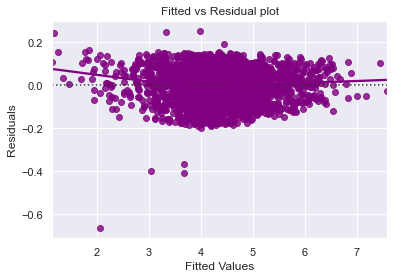

```python
# let's plot the fitted values vs residuals

sns.residplot(
    data=df_pred, x="Fitted Values", y="Residuals", color="purple", lowess=True
)
plt.xlabel("Fitted Values")
plt.ylabel("Residuals")
plt.title("Fitted vs Residual plot")
plt.show()
```

- The scatter plot shows the distribution of residuals (errors) vs fitted values (predicted values).
- If there exist any pattern in this plot, we consider it as signs of non-linearity in the data and a pattern means that the model doesn't capture non-linear effects.
- We see no pattern in the plot above. Hence, the assumptions of linearity and independence are satisfied.
- As a next step let us check for NORMALITY

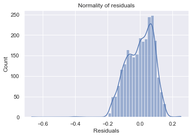

```python
sns.histplot(data=df_pred, x="Residuals", kde=True)
plt.title("Normality of residuals")
plt.show()
```

- The histogram of residuals does have a bell shape.
- Let's check the Q-Q plot.

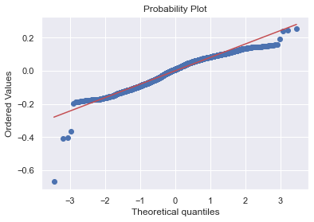

```python
import pylab
import scipy.stats as stats

stats.probplot(df_pred["Residuals"], dist="norm", plot=pylab)
plt.show()
```

- The residuals more or less follow a straight line except for the tails.
- Let's check the results of the Shapiro-Wilk test.

```python
stats.shapiro(df_pred["Residuals"])
```

```
ShapiroResult(statistic=0.9663722515106201, pvalue=1.0286592376205476e-23)
```

- Since p-value < 0.05, the residuals are not normal as per the Shapiro-Wilk test.
- Strictly speaking, the residuals are not normal.
- However, as an approximation, we can accept this distribution as close to being normal.
- So, the assumption is satisfied.

```python
import statsmodels.stats.api as sms
from statsmodels.compat import lzip

name = ["F statistic", "p-value"]
test = sms.het_goldfeldquandt(df_pred["Residuals"], x_train4)
lzip(name, test)
```

```
[('F statistic', 1.0585682546898179), ('p-value', 0.15795843676604734)]
```

- Since p-value > 0.05, we can say that the residuals are homoscedastic. So, this assumption is satisfied.

### Now that we have checked all the assumptions of linear regression and they are satisfied, we can move towards the prediction part.

```python
# predictions on the test set
pred = olsmod2.predict(x_test4)

df_pred_test = pd.DataFrame({"Actual": y_test, "Predicted": pred})
df_pred_test.sample(10, random_state=1)
```

|  | Actual | Predicted |
| --- | --- | --- |
| 2098 | 3.450622 | 3.454947 |
| 278 | 5.281527 | 5.295974 |
| 26 | 5.754666 | 5.696225 |
| 2910 | 4.510530 | 4.471335 |
| 2631 | 4.251348 | 4.165690 |
| 1582 | 4.506233 | 4.653222 |
| 2110 | 6.070230 | 5.978106 |
| 3160 | 4.194793 | 4.125101 |
| 2817 | 4.760206 | 4.659955 |
| 549 | 3.696103 | 3.784742 |

- We can observe here that our model has returned pretty good prediction results, and the actual and predicted values are comparable.
- We can also visualize comparison result as a bar graph. **Note**: As the number of records is large, for representation purpose, we are taking a sample of 25 records only.

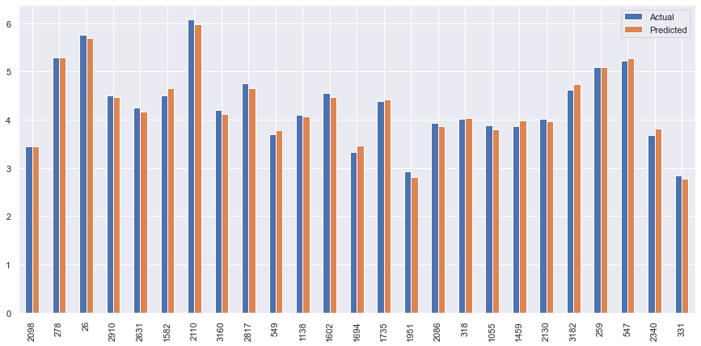

```python
df1 = df_pred_test.sample(25, random_state=1)
df1.plot(kind="bar", figsize=(15, 7))
plt.show()
```

```python
# checking model performance on train set (seen 70% data)
print("Training Performance\n")
olsmod2_train_perf = model_performance_regression(olsmod2, x_train4, y_train)
olsmod2_train_perf
```

```
Training Performance
```

|  | RMSE | MAE | R-squared | Adj. R-squared | MAPE |
| --- | --- | --- | --- | --- | --- |
| 0 | 0.08225 | 0.068232 | 0.989978 | 0.989949 | 1.666976 |

```python
# checking model performance on test set (seen 30% data)
print("Test Performance\n")
olsmod2_test_perf = model_performance_regression(olsmod2, x_test4, y_test)
olsmod2_test_perf
```

```
Test Performance
```

|  | RMSE | MAE | R-squared | Adj. R-squared | MAPE |
| --- | --- | --- | --- | --- | --- |
| 0 | 0.080501 | 0.068705 | 0.989901 | 0.989835 | 1.645273 |

**Let's compare the initial model created with sklearn and the final statsmodels model.**

```python
# training performance comparison

models_train_comp_df = pd.concat(
    [linearregression_train_perf.T, olsmod2_train_perf.T],
    axis=1,
)

models_train_comp_df.columns = [
    "Linear Regression sklearn",
    "Linear Regression statsmodels",
]

print("Training performance comparison:")
models_train_comp_df
```

```
Training performance comparison:
```

|  | Linear Regression sklearn | Linear Regression statsmodels |
| --- | --- | --- |
| RMSE | 0.081679 | 0.082250 |
| MAE | 0.067637 | 0.068232 |
| R-squared | 0.990116 | 0.989978 |
| Adj. R-squared | 0.989927 | 0.989949 |
| MAPE | 1.653169 | 1.666976 |

```python
# test performance comparison

models_test_comp_df = pd.concat(
    [linearregression_test_perf.T, olsmod2_test_perf.T],
    axis=1,
)

models_test_comp_df.columns = [
    "Linear Regression sklearn",
    "Linear Regression statsmodels",
]

print("Test performance comparison:")
models_test_comp_df
```

```
Test performance comparison:
```

|  | Linear Regression sklearn | Linear Regression statsmodels |
| --- | --- | --- |
| RMSE | 0.081059 | 0.080501 |
| MAE | 0.069047 | 0.068705 |
| R-squared | 0.989761 | 0.989901 |
| Adj. R-squared | 0.989291 | 0.989835 |
| MAPE | 1.650752 | 1.645273 |

- The performance of the two models is close to each other.

**Let's recreate the final statsmodels model and print it's summary to gain insights.**

```python
olsmodel_final = sm.OLS(y_train, x_train4).fit()
print(olsmodel_final.summary())
```

```
                                 OLS Regression Results
=======================================================================================
Dep. Variable:             used_price   R-squared (uncentered):                   1.000
Model:                            OLS   Adj. R-squared (uncentered):              1.000
Method:                 Least Squares   F-statistic:                          1.031e+06
Date:                Fri, 20 Aug 2021   Prob (F-statistic):                        0.00
Time:                        21:42:20   Log-Likelihood:                          2696.5
No. Observations:                2499   AIC:                                     -5379.
Df Residuals:                    2492   BIC:                                     -5338.
Df Model:                           7
Covariance Type:            nonrobust
=====================================================================================
                        coef    std err          t      P>|t|      [0.025      0.975]
-------------------------------------------------------------------------------------
selfie_camera_mp      0.0013      0.000      4.052      0.000       0.001       0.002
days_used            -0.0011   8.07e-06   -137.554      0.000      -0.001      -0.001
new_price             0.9761      0.001    737.070      0.000       0.974       0.979
battery_z_std         0.0054      0.002      2.791      0.005       0.002       0.009
brand_name_Gionee    -0.0388      0.013     -2.876      0.004      -0.065      -0.012
brand_name_Lenovo    -0.0196      0.008     -2.460      0.014      -0.035      -0.004
5g_yes                0.0368      0.009      3.945      0.000       0.018       0.055
==============================================================================
Omnibus:                      191.141   Durbin-Watson:                   2.039
Prob(Omnibus):                  0.000   Jarque-Bera (JB):              326.051
Skew:                          -0.562   Prob(JB):                     1.58e-71
Kurtosis:                       4.367   Cond. No.                     5.90e+03
==============================================================================

Notes:
[1] R² is computed without centering (uncentered) since the model does not contain a constant.
[2] Standard Errors assume that the covariance matrix of the errors is correctly specified.
[3] The condition number is large, 5.9e+03. This might indicate that there are
strong multicollinearity or other numerical problems.
```